# Week08 Assignment

Sophie Kim

April 13, 2016

# 1. Thee Normals

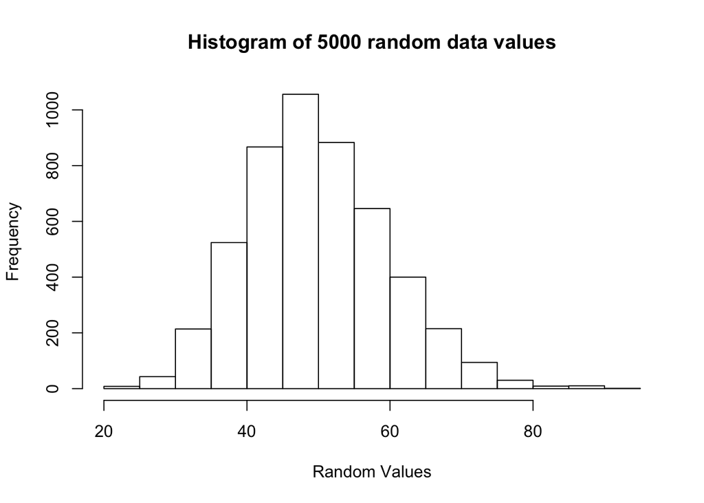

```r
rdist <- rchisq(5000, 50)

hist(rdist, main = "Histogram of 5000 random data values", xlab = "Random Values")
```

1.1 Zee scores

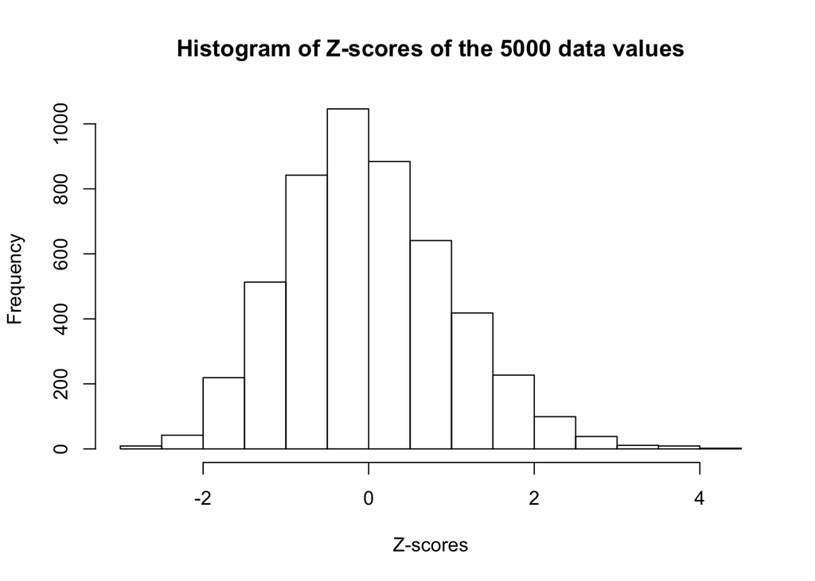

```r
zee <- c()

for (i in 1:5000) {
  zee[i] <- (rdist[i]-mean(rdist))/sd(rdist)
}

hist(zee, main = "Histogram of Z-scores of the 5000 data values", xlab = "Z-scores")
```

1.2 Shapiro will know

```r
shapiro.test(rdist)
```

```
##
##  Shapiro-Wilk normality test
##
## data:  rdist
## W = 0.99011, p-value < 2.2e-16
```

- The shapiro test tests for whether the distribution is a normal distribution.
- Because the result from the shapiro test shows that p-value is extremely small (< 0.01), we reject the null hypothesis that our distribution fits the normal distribution. So we can conclude that it does not fit the normal distribution.

1.3 A means to an end

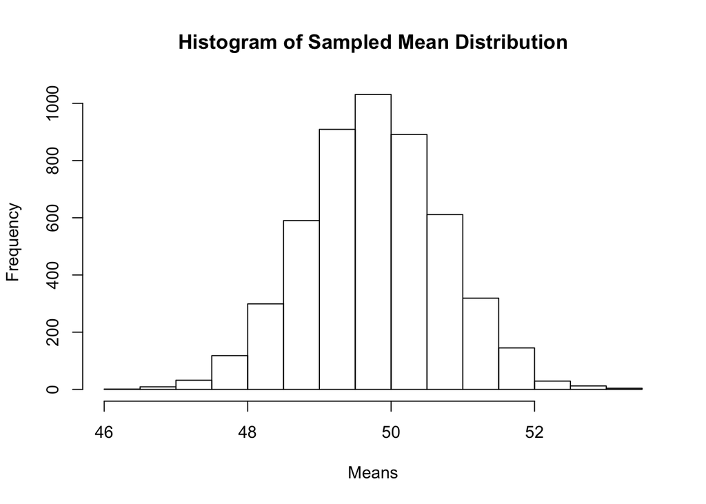

```r
meandist <- c()

for (i in 1:5000) {
  meandist[i] <-mean(sample(rdist, 100, replace = T))
}

hist(meandist, main = "Histogram of Sampled Mean Distribution", xlab = "Means")
```

```r
shapiro.test(meandist)
```

```
##
##  Shapiro-Wilk normality test
##
## data:  meandist
## W = 0.99975, p-value = 0.8483
```

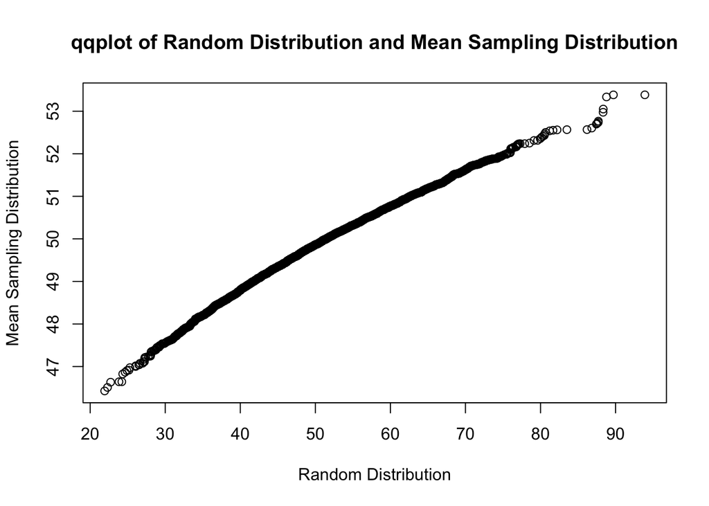

```r
qqplot(rdist, meandist, main = "qqplot of Random Distribution and Mean Sampling Distribution", xlab = "Random Distribution", ylab = "Mean Sampling Distribution")
```

# 2. Lactose

The file “lactase_haplotype.txt” has haplotype information for the C/T-13910 SNP in the Finnish population. Read in and store this data.

```r
lactase <- read.table("lactase_haplotypes.txt", header = T)
```

Calculate genetic diversity for each SNP 1-6. aggregate() is useful here to pull together the numbers by each marker.

```r
1 - sum((aggregate(N~SNP1, lactase, sum)$N / 106)^2)
```

```
## [1] 0.4761481
```

```r
1 - sum((aggregate(N~SNP2, lactase, sum)$N / 106)^2)
```

```
## [1] 0.491456
```

```r
1 - sum((aggregate(N~SNP3, lactase, sum)$N / 106)^2)
```

```
## [1] 0.4822001
```

```r
1 - sum((aggregate(N~SNP4, lactase, sum)$N / 106)^2)
```

```
## [1] 0.4750801
```

```r
1 - sum((aggregate(N~SNP5, lactase, sum)$N / 106)^2)
```

```
## [1] 0.3889284
```

```r
1 - sum((aggregate(N~SNP6, lactase, sum)$N / 106)^2)
```

```
## [1] 0.4829121
```

Determine linkage disequilibrium between each marker of haplotype A and the T allele for the C/T-13910 SNP using the D statistic.

– SNP1

```r
aggregate(N~SNP1, lactase, sum)
```

```
##   SNP1  N
## 1    A 70
## 2    G 31
## 3    T  5
```

```r
aggregate(N~C.T.13910, lactase, sum)
```

```
##   C.T.13910  N
## 1         C 33
## 2         T 73
```

```r
A1 <- 70/106
CTT <- 73/106

aggregate(N~SNP1:C.T.13910, lactase, sum)
```

```
##   SNP1 C.T.13910  N
## 1    A         C 20
## 2    G         C  8
## 3    T         C  5
## 4    A         T 50
## 5    G         T 23
```

```r
A1CTT <- 50/106

result1 <- A1CTT - A1 * CTT
```

– SNP2

```r
aggregate(N~SNP2, lactase, sum)
```

```
##   SNP2  N
## 1    A 72
## 2    C  5
## 3    G  8
## 4    T 21
```

```r
aggregate(N~C.T.13910, lactase, sum)
```

```
##   C.T.13910  N
## 1         C 33
## 2         T 73
```

```r
A2 <- 72/106
CTT <- 73/106

aggregate(N~SNP2:C.T.13910, lactase, sum)
```

```
##   SNP2 C.T.13910  N
## 1    A         C  8
## 2    C         C  5
## 3    G         C  8
## 4    T         C 12
## 5    A         T 64
## 6    T         T  9
```

```r
A2CTT <- 64/106

result2 <- A2CTT - A2 * CTT
```

– SNP3

```r
aggregate(N~SNP3, lactase, sum)
```

```
##   SNP3  N
## 1    A 20
## 2    C  8
## 3    G 73
## 4    T  5
```

```r
aggregate(N~C.T.13910, lactase, sum)
```

```
##   C.T.13910  N
## 1         C 33
## 2         T 73
```

```r
A3 <- 73/106
CTT <- 73/106

aggregate(N~SNP3:C.T.13910, lactase, sum)
```

```
##   SNP3 C.T.13910  N
## 1    A         C 20
## 2    C         C  8
## 3    T         C  5
## 4    G         T 73
```

```r
A3CTT <- 73/106

result3 <- A3CTT - A3 * CTT
```

– SNP4

```r
aggregate(N~SNP4, lactase, sum)
```

```
##   SNP4  N
## 1    A 73
## 2    G 20
## 3    T 13
```

```r
aggregate(N~C.T.13910, lactase, sum)
```

```
##   C.T.13910  N
## 1         C 33
## 2         T 73
```

```r
A4 <- 73/106
CTT <- 73/106

aggregate(N~SNP4:C.T.13910, lactase, sum)
```

```
##   SNP4 C.T.13910  N
## 1    G         C 20
## 2    T         C 13
## 3    A         T 73
```

```r
A4CTT <- 73/106

result4 <- A4CTT - A4 * CTT
```

– SNP5

```r
aggregate(N~SNP5, lactase, sum)
```

```
##   SNP5  N
## 1    A 21
## 2    C  5
## 3    T 80
```

```r
aggregate(N~C.T.13910, lactase, sum)
```

```
##   C.T.13910  N
## 1         C 33
## 2         T 73
```

```r
A5 <- 80/106
CTT <- 73/106

aggregate(N~SNP5:C.T.13910, lactase, sum)
```

```
##   SNP5 C.T.13910  N
## 1    A         C 12
## 2    C         C  5
## 3    T         C 16
## 4    A         T  9
## 5    T         T 64
```

```r
A5CTT <- 64/106

result5 <- A5CTT - A5 * CTT
```

– SNP6

```r
aggregate(N~SNP6, lactase, sum)
```

```
##   SNP6  N
## 1    A 32
## 2    G  5
## 3    T 69
```

```r
aggregate(N~C.T.13910, lactase, sum)
```

```
##   C.T.13910  N
## 1         C 33
## 2         T 73
```

```r
A6 <- 69/106
CTT <- 73/106

aggregate(N~SNP6:C.T.13910, lactase, sum)
```

```
##   SNP6 C.T.13910  N
## 1    G         C  5
## 2    T         C 28
## 3    A         T 32
## 4    T         T 41
```

```r
A6CTT <- 41/106

result6 <- A6CTT - A6 * CTT
```

Plot the linkage disequilibrium D (calculated above) between SNP T-13910 and the adjacent markers. Assume even spacing of the markers.

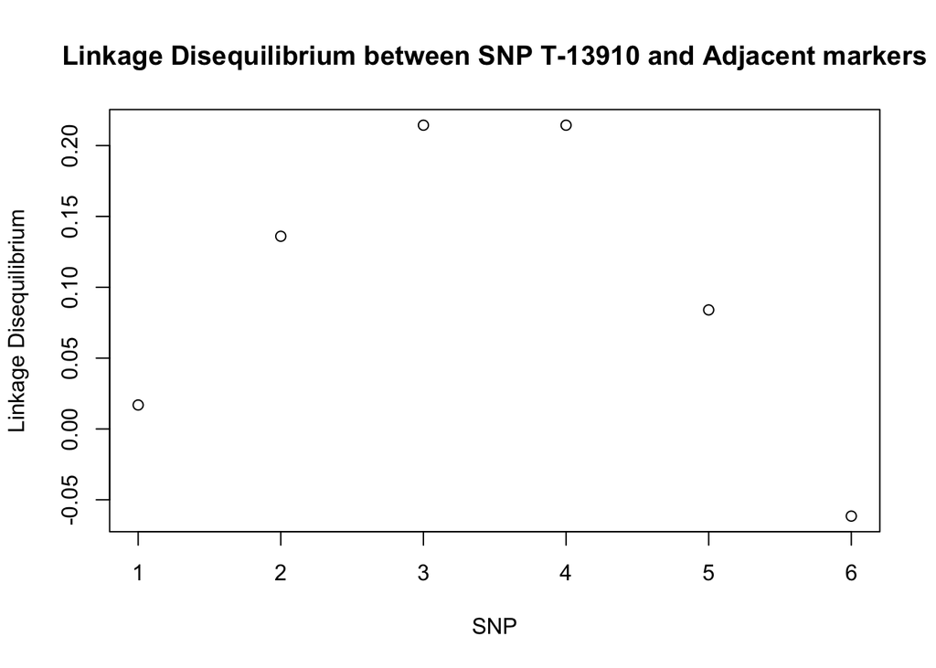

```r
dV <- c(result1, result2, result3, result4, result5, result6)

plot(dV, main = "Linkage Disequilibrium between SNP T-13910 and Adjacent markers", xlab = "SNP", ylab = "Linkage Disequilibrium")
```

# 3. Chopping up characters

Read in the file “SequenceData.txt”. This file contains sequences (each 50 bp long) from 100 individuals.

```r
seq <- read.table("SequenceData.txt")
```

How many unique haplotypes does the data contain?

```r
table(seq)
```

```
## seq
## AACTGTATATGTCATTGCTCGAATTGCGTTAGCTGATGGATGGAATAGTC
##                                                  1
## ACAGATGTATGTCATTGCTCGAATTGCGTTAGCTGATGGGTATAATTGTA
##                                                  1
## ACCCACAGTTGTCATTGCTCGAATTGCGTTAGCTGATGGGGATAACGGTA
##                                                  1
## ACCCGAAATTGTCATTGCTCGAATTGCGTTAGCTGATGGCTCTCATCGTT
##                                                  1
## AGACAAGTCCGTCATTGCTCGAATTGCGTTAGCTGATGGTTAAACTCGAA
##                                                  1
## AGACTAATTCGTCATTGCTCGAATTGCGTGAGCTGATGGGCTCAATCGGC
##                                                  1
## AGCACCACACGTCATTGCTCGAATTGCGTTAGCTGATGGGCATACTCCCC
##                                                  1
## AGCCAAATACGTCATTGCTCGAATTGCGTTAGCTGATGGATATAATCGTA
##                                                  1
## AGCCAAATACGTCATTGCTCGAATTGCGTTAGCTGATGGGTATAATCGTA
##                                                  2
## AGCCAAATAGGTCATTGCTCGAATTGCGTTAGCTAATGGGTATAATCGTA
##                                                  1
## AGCCAAATATATCATTGCTCGAATTGCGTTGGCTGATGGGTATAATCGTA
##                                                  1
## AGCCAAATATGACATTGCTCGAATTGCGTTTGCTGATGGGTATAATCGTA
##                                                  1
## AGCCAAATATGCCATTGCTCGAATTGCGTTAGCTGAGGGGTATAATCGTA
##                                                  1
## AGCCAAATATGTCATTACCCGAATTGCGTTAGCTGATGGGTATAATCGTA
##                                                  1
## AGCCAAATATGTCATTGATCGAATTGCGTTAGCTCATGGGTATAATCGTA
##                                                  1
## AGCCAAATATGTCATTGCTCGAATTGCGTGAGCTGATGGGTATAATCGTA
##                                                  1
## AGCCAAATATGTCATTGCTCGAATTGCGTTAGCCGATGGGTATAATCGTA
##                                                  1
## AGCCAAATATGTCATTGCTCGAATTGCGTTAGCTGATGGGTATAATCGTA
##                                                 62
## AGCCAAATATGTCATTGCTCGAATTGCGTTATCTGATGGTTATAATCGTA
##                                                  1
## AGCCAAATATGTCATTGCTCGAATTGCGTTGGCTGATGGGTATAATCGTA
```

[output cut: 22 more lines]

```
##                                                  1
## CGCTAAAAATGTCATTGCTCGAATTGCGTTAGCTGATGGGTATCTTCGTA
##                                                  1
## CGGAAATTACGTCATTGCTCGAATTGCGTTAGCTGATGGGTGTGCTAGTA
##                                                  1
## GGCCGAATATGTCATTGCTCGAATTGCGTTAGCTGATGGCGTTAATAGCA
##                                                  1
## GTCTAAATATGTCATTGCTCGAATTGCGTTAGCTGATGGGTATTGTGTTA
##                                                  1
## TAGCCAATGCGTCATTGCTCGAATTGCGTTAGCAGATGGGTATACGAGTA
##                                                  1
## TAGTCAATACGTCATTGCTCGAATTGCGTTAGCTGATGGGGAAAATCGTA
##                                                  1
## TGTACAATGTGTCATTGCTCGAATTGCGTTAGCTGATGGATACAATCGCA
##                                                  1
```

```r
length(table(seq))
```

```
## [1] 38
```

– Therefore, 38 unique haplotypes exist in this data.

How many segregating (polymorphic) sites does the data contain?

```r
seq1 <- t(apply(seq, 1, function(x) {
  unlist(strsplit(x, ""))
}))

seq2 <- data.frame(seq1)

seq3 <- apply(seq2, 2, function(x) {
  length(table(x))
})

seq3
```

```
##  V11  V12  V13  V14  V15  V16  V17  V18  V19 V110 V111 V112 V113 V114 V115
##    4    4    4    4    4    3    4    4    4    3    3    3    1    3    1
## V116 V117 V118 V119 V120 V121 V122 V123 V124 V125 V126 V127 V128 V129 V130
##    1    2    3    2    2    1    1    1    1    1    1    1    1    1    2
## V131 V132 V133 V134 V135 V136 V137 V138 V139 V140 V141 V142 V143 V144 V145
##    3    2    2    4    3    1    2    1    2    4    4    4    4    4    4
## V146 V147 V148 V149 V150
##    4    4    3    4    4
```

– >1 means polymorphic. Therefore, this data contains 36 polymorphic sites.

Calculate genetic diversity for the each nucleotide position in the sequence.

```r
final <- c()

for (k in 1:50) {

  a = 0
  t = 0
  c = 0
  g = 0

  for (i in 1:100) {
    if (seq1[i, k] == "A") {
      a = a + 1
    }
    if (seq1[i, k] == "T") {
      t = t + 1
    }
    if (seq1[i, k] == "C") {
      c = c + 1
    }
    if (seq1[i, k] == "G") {
      g = g + 1
    }
  }

  result = 1 - ((a/100)^2 + (t/100)^2 + (c/100)^2 + (g/100)^2)
  final[k] <- result
}

final
```

```
##  [1] 0.1334 0.1514 0.1690 0.2038 0.2030 0.1144 0.1150 0.1150 0.1514 0.2152
## [11] 0.0394 0.0394 0.0000 0.0394 0.0000 0.0000 0.0198 0.0394 0.0198 0.0198
## [21] 0.0000 0.0000 0.0000 0.0000 0.0000 0.0000 0.0000 0.0000 0.0000 0.0392
## [31] 0.0586 0.0198 0.0198 0.0588 0.0394 0.0000 0.0198 0.0000 0.0198 0.2374
## [41] 0.1864 0.1692 0.1150 0.1332 0.1330 0.0966 0.1684 0.0586 0.1146 0.1506
```

– The variable final stores the genetic diversities for each nucleotide position in the sequence.